# Clustering Data

```python
import pandas as pd
import numpy as np
import matplotlib.pyplot as plt
%matplotlib inline
import seaborn as sns
pd.options.display.float_format = '{:.2f}'.format
import warnings
warnings.filterwarnings('ignore')

from sklearn.cluster import KMeans
from sklearn.metrics import silhouette_score
from mpl_toolkits.mplot3d import Axes3D

import plotly.express as px
import kaleido
```

```python
data = pd.read_csv('Country-data.csv')
data.head()
```

|  | country | child_mort | exports | health | imports | income | inflation | life_expec | total_fer | gdpp |
| --- | --- | --- | --- | --- | --- | --- | --- | --- | --- | --- |
| 0 | Afghanistan | 90.20 | 10.00 | 7.58 | 44.90 | 1610 | 9.44 | 56.20 | 5.82 | 553 |
| 1 | Albania | 16.60 | 28.00 | 6.55 | 48.60 | 9930 | 4.49 | 76.30 | 1.65 | 4090 |
| 2 | Algeria | 27.30 | 38.40 | 4.17 | 31.40 | 12900 | 16.10 | 76.50 | 2.89 | 4460 |
| 3 | Angola | 119.00 | 62.30 | 2.85 | 42.90 | 5900 | 22.40 | 60.10 | 6.16 | 3530 |
| 4 | Antigua and Barbuda | 10.30 | 45.50 | 6.03 | 58.90 | 19100 | 1.44 | 76.80 | 2.13 | 12200 |

```python
data.shape
```

```
(167, 10)
```

```python
data.columns
```

```
Index(['country', 'child_mort', 'exports', 'health', 'imports', 'income',
       'inflation', 'life_expec', 'total_fer', 'gdpp'],
      dtype='object')
```

```python
data.info()
```

```
<class 'pandas.core.frame.DataFrame'>
RangeIndex: 167 entries, 0 to 166
Data columns (total 10 columns):
 #   Column      Non-Null Count  Dtype
---  ------      --------------  -----
 0   country     167 non-null    object
 1   child_mort  167 non-null    float64
 2   exports     167 non-null    float64
 3   health      167 non-null    float64
 4   imports     167 non-null    float64
 5   income      167 non-null    int64
 6   inflation   167 non-null    float64
 7   life_expec  167 non-null    float64
 8   total_fer   167 non-null    float64
 9   gdpp        167 non-null    int64
dtypes: float64(7), int64(2), object(1)
memory usage: 13.2+ KB
```

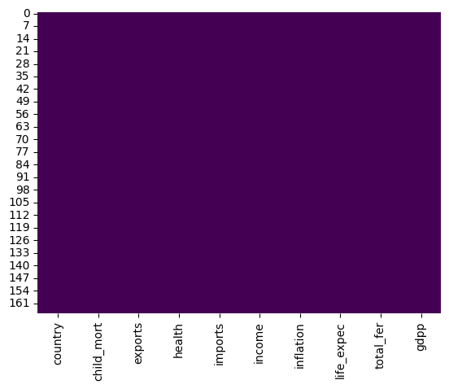

```python
sns.heatmap(data.isnull(), cmap='viridis', cbar=False)
```

```python
data.describe()
```

|  | child_mort | exports | health | imports | income | inflation | life_expec | total_fer | gdpp |
| --- | --- | --- | --- | --- | --- | --- | --- | --- | --- |
| count | 167.00 | 167.00 | 167.00 | 167.00 | 167.00 | 167.00 | 167.00 | 167.00 | 167.00 |
| mean | 38.27 | 41.11 | 6.82 | 46.89 | 17144.69 | 7.78 | 70.56 | 2.95 | 12964.16 |
| std | 40.33 | 27.41 | 2.75 | 24.21 | 19278.07 | 10.57 | 8.89 | 1.51 | 18328.70 |
| min | 2.60 | 0.11 | 1.81 | 0.07 | 609.00 | -4.21 | 32.10 | 1.15 | 231.00 |
| 25% | 8.25 | 23.80 | 4.92 | 30.20 | 3355.00 | 1.81 | 65.30 | 1.79 | 1330.00 |
| 50% | 19.30 | 35.00 | 6.32 | 43.30 | 9960.00 | 5.39 | 73.10 | 2.41 | 4660.00 |
| 75% | 62.10 | 51.35 | 8.60 | 58.75 | 22800.00 | 10.75 | 76.80 | 3.88 | 14050.00 |
| max | 208.00 | 200.00 | 17.90 | 174.00 | 125000.00 | 104.00 | 82.80 | 7.49 | 105000.00 |

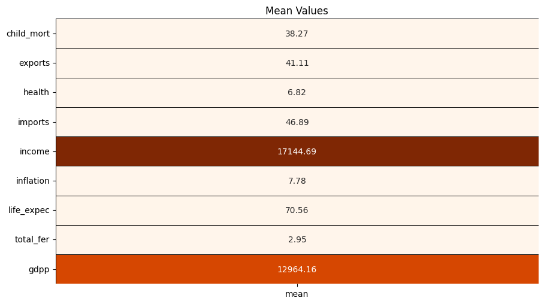

```python
fig, ax = plt.subplots(nrows=1, ncols=1, figsize=(10, 6))

colors = ['#FF781F', '#2D2926']
plt.subplot(1, 1, 1)
sns.heatmap(data.describe().T[['mean']], cmap='Oranges', annot=True, fmt='.2f', linecolor='black', linewidths=0.4, cbar=False)
plt.title('Mean Values')
fig.tight_layout(pad=4)
```

```python
col = list(data.columns)
col.remove('country')
categorical_features = ['country']
numerical_features = [*col]
print('Categorical Features:', *categorical_features)
print('Numerical Features:', *numerical_features)
```

```
Categorical Features: country
Numerical Features: child_mort exports health imports income inflation life_expec total_fer gdpp
```

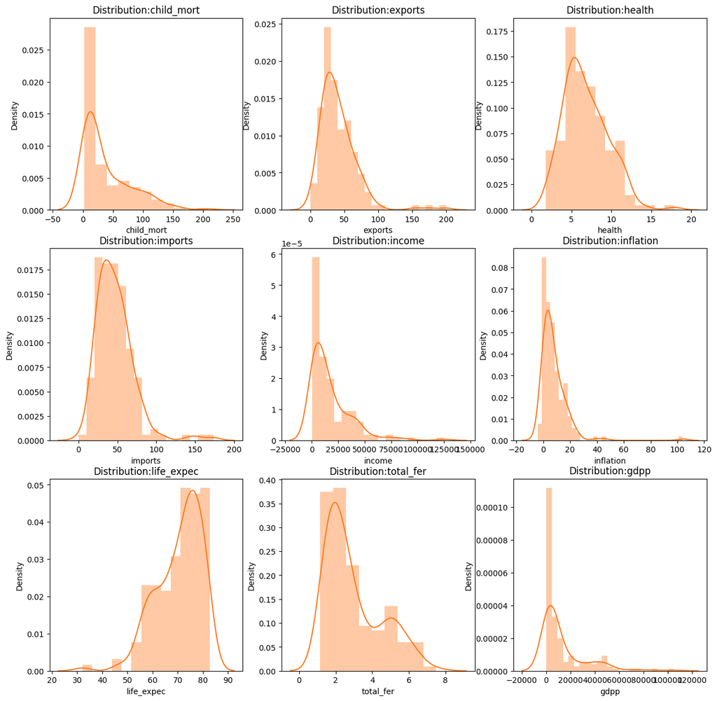

```python
fig, ax = plt.subplots(nrows=3, ncols=3, figsize=(15, 15))
for i in range(len(numerical_features)):
    plt.subplot(3,3,i+1)
    sns.distplot(data[numerical_features[i]], color = colors[0])
    title = 'Distribution:' + numerical_features[i]
    plt.title(title)
plt.show()
```

```python
len(data['country'].unique()) == len(data)
```

```
True
```

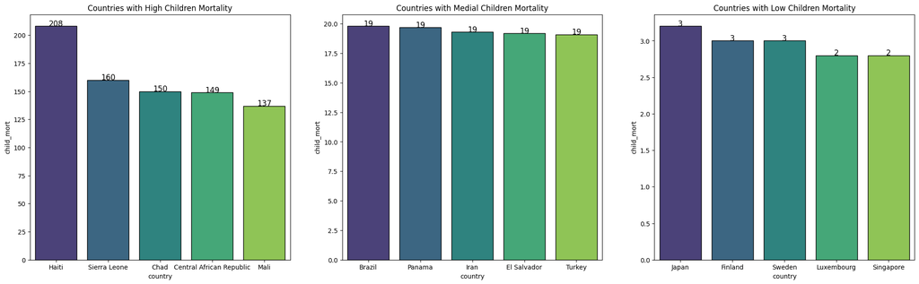

```python
fig = plt.subplots(nrows = 1, ncols = 3, figsize = (25,7))
plt.subplot(1, 3, 1)
ax = sns.barplot(x = 'country', y = 'child_mort', data = data.sort_values(ascending = False, by = 'child_mort').iloc[:5],palette = 'viridis', edgecolor = 'black');
plt.title('Countries with High Children Mortality')
for rect in ax.patches:
    ax.text(rect.get_x() + rect.get_width() / 2, rect.get_height(), int(rect.get_height()),
            horizontalalignment='center', fontsize = 12)

plt.subplot(1,3,2)
ax = sns.barplot(x = 'country', y = 'child_mort', data = data.sort_values(ascending = False, by = 'child_mort').iloc[81:86],palette = 'viridis', edgecolor = 'black');
plt.title('Countries with Medial Children Mortality')
for rect in ax.patches:
    ax.text(rect.get_x() + rect.get_width()/2, rect.get_height(), int(rect.get_height()),
            horizontalalignment='center', fontsize = 12)

plt.subplot(1,3,3)
ax = sns.barplot(x = 'country', y = 'child_mort', data = data.sort_values(ascending = False, by = 'child_mort').iloc[161:166],palette = 'viridis', edgecolor = 'black');
plt.title('Countries with Low Children Mortality')
for rect in ax.patches:
    ax.text(rect.get_x() + rect.get_width()/2, rect.get_height(), int(rect.get_height()),
            horizontalalignment='center', fontsize = 12)
plt.show()
```

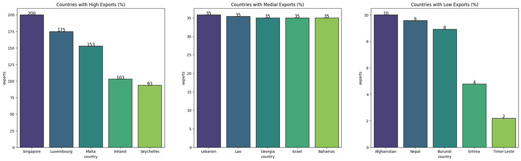

```python
fig = plt.subplots(nrows = 1, ncols = 3, figsize = (25,7))
plt.subplot(1, 3, 1)
ax = sns.barplot(x = 'country', y = 'exports', data = data.sort_values(ascending = False, by = 'exports').iloc[:5],palette = 'viridis', edgecolor = 'black');
plt.title('Countries with High Exports (%)')
for rect in ax.patches:
    ax.text(rect.get_x() + rect.get_width() / 2, rect.get_height(), int(rect.get_height()),
            horizontalalignment='center', fontsize = 12)

plt.subplot(1,3,2)
ax = sns.barplot(x = 'country', y = 'exports', data = data.sort_values(ascending = False, by = 'exports').iloc[81:86],palette = 'viridis', edgecolor = 'black');
plt.title('Countries with Medial Exports (%)')
for rect in ax.patches:
    ax.text(rect.get_x() + rect.get_width() / 2, rect.get_height(), int(rect.get_height()),
            horizontalalignment='center', fontsize = 12)

plt.subplot(1,3,3)
ax = sns.barplot(x = 'country', y = 'exports', data = data.sort_values(ascending = False, by = 'exports').iloc[161:166],palette = 'viridis', edgecolor = 'black');
plt.title('Countries with Low Exports (%)')
for rect in ax.patches:
    ax.text(rect.get_x() + rect.get_width() / 2, rect.get_height(), int(rect.get_height()),
            horizontalalignment='center', fontsize = 12)
plt.show()
```

[figure not shown]

```python
fig = plt.subplots(nrows = 1, ncols = 3, figsize = (25,7))
plt.subplot(1, 3, 1)
ax = sns.barplot(x = 'country', y = 'imports', data = data.sort_values(ascending = False, by = 'health').iloc[:5],palette = 'viridis', edgecolor = 'black');
plt.title('Countries with High Health Spending (%)')
for rect in ax.patches:
    ax.text(rect.get_x() + rect.get_width() / 2, rect.get_height(), int(rect.get_height()),
            horizontalalignment='center', fontsize = 12)

plt.subplot(1,3,2)
ax = sns.barplot(x = 'country', y = 'health', data = data.sort_values(ascending = False, by = 'health').iloc[81:86],palette = 'viridis', edgecolor = 'black');
plt.title('Countries with Medial Health Spending (%)')
for rect in ax.patches:
    ax.text(rect.get_x() + rect.get_width() / 2, rect.get_height(), int(rect.get_height()),
            horizontalalignment='center', fontsize = 12)

plt.subplot(1,3,3)
ax = sns.barplot(x = 'country', y = 'health', data = data.sort_values(ascending = False, by = 'health').iloc[161:166],palette = 'viridis', edgecolor = 'black');
plt.title('Countries with Low Health Spending (%)')
for rect in ax.patches:
    ax.text(rect.get_x() + rect.get_width() / 2, rect.get_height(), int(rect.get_height()),
            horizontalalignment='center', fontsize = 12)
plt.show()
```

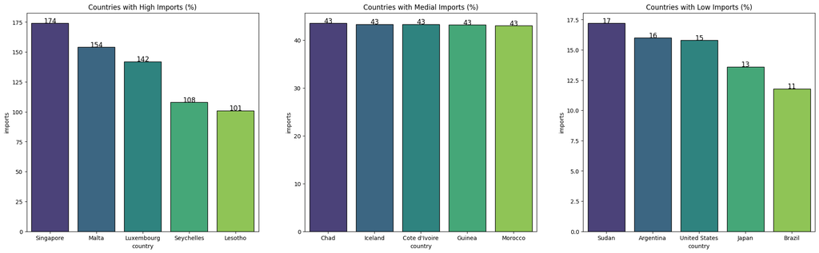

```python
fig = plt.subplots(nrows = 1, ncols = 3, figsize = (25,7))
plt.subplot(1, 3, 1)
ax = sns.barplot(x = 'country', y = 'imports', data = data.sort_values(ascending = False, by = 'imports').iloc[:5],palette = 'viridis', edgecolor = 'black');
plt.title('Countries with High Imports (%)')
for rect in ax.patches:
    ax.text(rect.get_x() + rect.get_width() / 2, rect.get_height(), int(rect.get_height()),
            horizontalalignment='center', fontsize = 12)

plt.subplot(1,3,2)
ax = sns.barplot(x = 'country', y = 'imports', data = data.sort_values(ascending = False, by = 'imports').iloc[81:86],palette = 'viridis', edgecolor = 'black');
plt.title('Countries with Medial Imports (%)')
for rect in ax.patches:
    ax.text(rect.get_x() + rect.get_width() / 2, rect.get_height(), int(rect.get_height()),
            horizontalalignment='center', fontsize = 12)

plt.subplot(1,3,3)
ax = sns.barplot(x = 'country', y = 'imports', data = data.sort_values(ascending = False, by = 'imports').iloc[161:166],palette = 'viridis', edgecolor = 'black');
plt.title('Countries with Low Imports (%)')
for rect in ax.patches:
    ax.text(rect.get_x() + rect.get_width() / 2, rect.get_height(), int(rect.get_height()),
            horizontalalignment='center', fontsize = 12)
plt.show()
```

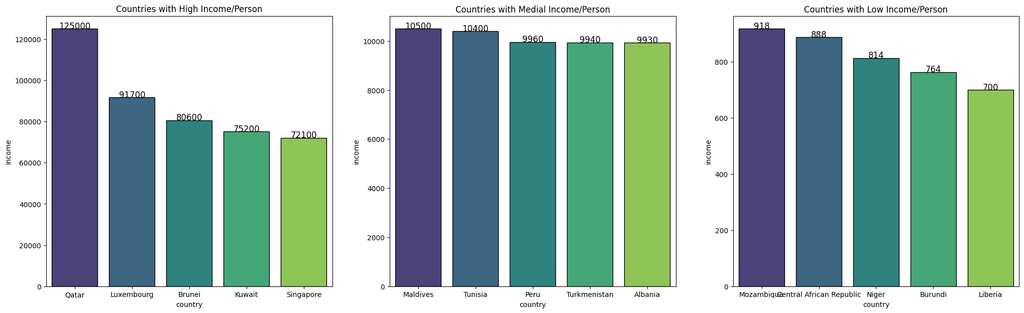

```python
fig = plt.subplots(nrows = 1, ncols = 3, figsize = (25,7))
plt.subplot(1, 3, 1)
ax = sns.barplot(x = 'country', y = 'income', data = data.sort_values(ascending = False, by = 'income').iloc[:5],palette = 'viridis', edgecolor = 'black');
plt.title('Countries with High Income/Person')
for rect in ax.patches:
    ax.text(rect.get_x() + rect.get_width() / 2, rect.get_height(), int(rect.get_height()),
            horizontalalignment='center', fontsize = 12)

plt.subplot(1,3,2)
ax = sns.barplot(x = 'country', y = 'income', data = data.sort_values(ascending = False, by = 'income').iloc[81:86],palette = 'viridis', edgecolor = 'black');
plt.title('Countries with Medial Income/Person')
for rect in ax.patches:
    ax.text(rect.get_x() + rect.get_width() / 2, rect.get_height(), int(rect.get_height()),
            horizontalalignment='center', fontsize = 12)

plt.subplot(1,3,3)
ax = sns.barplot(x = 'country', y = 'income', data = data.sort_values(ascending = False, by = 'income').iloc[161:166],palette = 'viridis', edgecolor = 'black');
plt.title('Countries with Low Income/Person')
for rect in ax.patches:
    ax.text(rect.get_x() + rect.get_width() / 2, rect.get_height(), int(rect.get_height()),
            horizontalalignment='center', fontsize = 12)
plt.show()
```

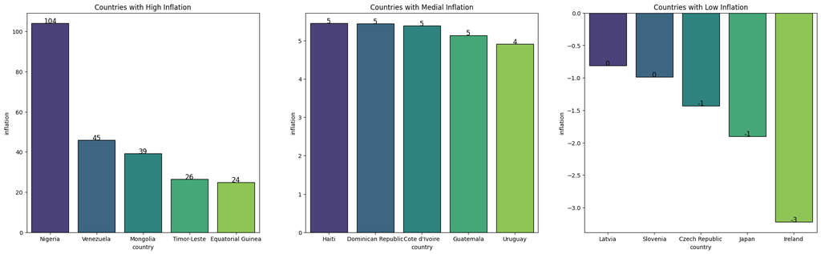

```python
fig = plt.subplots(nrows = 1, ncols = 3, figsize = (25,7))
plt.subplot(1, 3, 1)
ax = sns.barplot(x = 'country', y = 'inflation', data = data.sort_values(ascending = False, by = 'inflation').iloc[:5],palette = 'viridis', edgecolor = 'black');
plt.title('Countries with High Inflation')
for rect in ax.patches:
    ax.text(rect.get_x() + rect.get_width() / 2, rect.get_height(), int(rect.get_height()),
            horizontalalignment='center', fontsize = 12)

plt.subplot(1,3,2)
ax = sns.barplot(x = 'country', y = 'inflation', data = data.sort_values(ascending = False, by = 'inflation').iloc[81:86],palette = 'viridis', edgecolor = 'black');
plt.title('Countries with Medial Inflation')
for rect in ax.patches:
    ax.text(rect.get_x() + rect.get_width() / 2, rect.get_height(), int(rect.get_height()),
            horizontalalignment='center', fontsize = 12)

plt.subplot(1,3,3)
ax = sns.barplot(x = 'country', y = 'inflation', data = data.sort_values(ascending = False, by = 'inflation').iloc[161:166],palette = 'viridis', edgecolor = 'black');
plt.title('Countries with Low Inflation')
for rect in ax.patches:
    ax.text(rect.get_x() + rect.get_width() / 2, rect.get_height(), int(rect.get_height()),
            horizontalalignment='center', fontsize = 12)
plt.show()
```

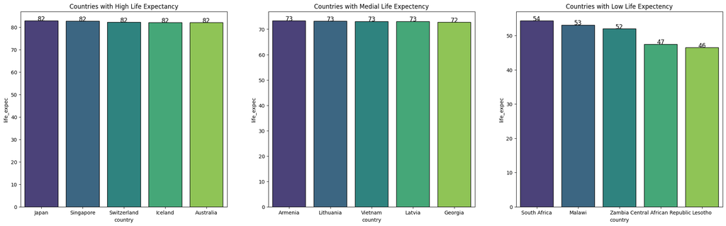

```python
fig = plt.subplots(nrows = 1, ncols = 3, figsize = (25,7))
plt.subplot(1, 3, 1)
ax = sns.barplot(x = 'country', y = 'life_expec', data = data.sort_values(ascending = False, by = 'life_expec').iloc[:5],palette = 'viridis', edgecolor = 'black');
plt.title('Countries with High Life Expectancy')
for rect in ax.patches:
    ax.text(rect.get_x() + rect.get_width() / 2, rect.get_height(), int(rect.get_height()),
            horizontalalignment='center', fontsize = 12)

plt.subplot(1,3,2)
ax = sns.barplot(x = 'country', y = 'life_expec', data = data.sort_values(ascending = False, by = 'life_expec').iloc[81:86],palette = 'viridis', edgecolor = 'black');
plt.title('Countries with Medial Life Expectency')
for rect in ax.patches:
    ax.text(rect.get_x() + rect.get_width() / 2, rect.get_height(), int(rect.get_height()),
            horizontalalignment='center', fontsize = 12)

plt.subplot(1,3,3)
ax = sns.barplot(x = 'country', y = 'life_expec', data = data.sort_values(ascending = False, by = 'life_expec').iloc[161:166],palette = 'viridis', edgecolor = 'black');
plt.title('Countries with Low Life Expectency')
for rect in ax.patches:
    ax.text(rect.get_x() + rect.get_width() / 2, rect.get_height(), int(rect.get_height()),
            horizontalalignment='center', fontsize = 12)
plt.show()
```

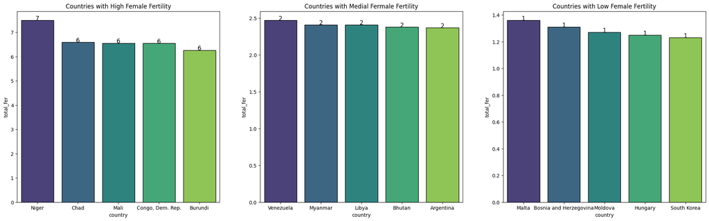

```python
fig = plt.subplots(nrows = 1, ncols = 3, figsize = (25,7))
plt.subplot(1, 3, 1)
ax = sns.barplot(x = 'country', y = 'total_fer', data = data.sort_values(ascending = False, by = 'total_fer').iloc[:5],palette = 'viridis', edgecolor = 'black');
plt.title('Countries with High Female Fertility')
for rect in ax.patches:
    ax.text(rect.get_x() + rect.get_width() / 2, rect.get_height(), int(rect.get_height()),
            horizontalalignment='center', fontsize = 12)

plt.subplot(1,3,2)
ax = sns.barplot(x = 'country', y = 'total_fer', data = data.sort_values(ascending = False, by = 'total_fer').iloc[81:86],palette = 'viridis', edgecolor = 'black');
plt.title('Countries with Medial Fermale Fertility')
for rect in ax.patches:
    ax.text(rect.get_x() + rect.get_width() / 2, rect.get_height(), int(rect.get_height()),
            horizontalalignment='center', fontsize = 12)

plt.subplot(1,3,3)
ax = sns.barplot(x = 'country', y = 'total_fer', data = data.sort_values(ascending = False, by = 'total_fer').iloc[161:166],palette = 'viridis', edgecolor = 'black');
plt.title('Countries with Low Female Fertility')
for rect in ax.patches:
    ax.text(rect.get_x() + rect.get_width() / 2, rect.get_height(), int(rect.get_height()),
            horizontalalignment='center', fontsize = 12)
plt.show()
```

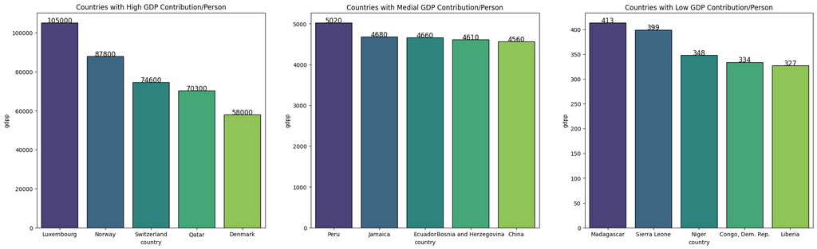

```python
fig = plt.subplots(nrows = 1, ncols = 3, figsize = (25,7))
plt.subplot(1, 3, 1)
ax = sns.barplot(x = 'country', y = 'gdpp', data = data.sort_values(ascending = False, by = 'gdpp').iloc[:5],palette = 'viridis', edgecolor = 'black');
plt.title('Countries with High GDP Contribution/Person')
for rect in ax.patches:
    ax.text(rect.get_x() + rect.get_width() / 2, rect.get_height(), int(rect.get_height()),
            horizontalalignment='center', fontsize = 12)

plt.subplot(1,3,2)
ax = sns.barplot(x = 'country', y = 'gdpp', data = data.sort_values(ascending = False, by = 'gdpp').iloc[81:86],palette = 'viridis', edgecolor = 'black');
plt.title('Countries with Medial GDP Contribution/Person')
for rect in ax.patches:
    ax.text(rect.get_x() + rect.get_width() / 2, rect.get_height(), int(rect.get_height()),
            horizontalalignment='center', fontsize = 12)

plt.subplot(1,3,3)
ax = sns.barplot(x = 'country', y = 'gdpp', data = data.sort_values(ascending = False, by = 'gdpp').iloc[161:166],palette = 'viridis', edgecolor = 'black');
plt.title('Countries with Low GDP Contribution/Person')
for rect in ax.patches:
    ax.text(rect.get_x() + rect.get_width() / 2, rect.get_height(), int(rect.get_height()),
            horizontalalignment='center', fontsize = 12)
plt.show()
```

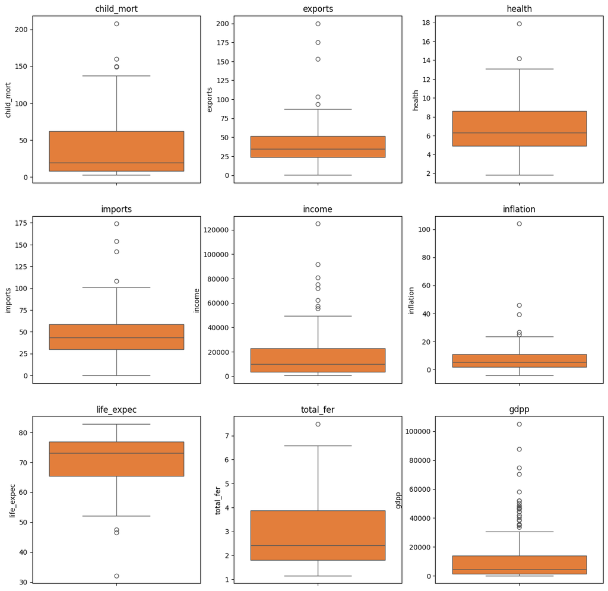

```python
fig = plt.subplots(nrows = 3, ncols = 3, figsize = (15,15))
for i in range(len(numerical_features)):
    plt.subplot(3,3,i+1)
    ax = sns.boxplot(data[numerical_features[i]], color = colors[0])
    plt.title(numerical_features[i])
plt.show()
```

Summary of Data Analysis:

- When it comes to health conditions, African countries hold higher ranks in all the wrong situations. They hold a significant presence in high Children Mortality, Low Life Expectency and Highest Total Fertility.
- All these problems are already pretty serious and hence it is very important to assist them during the periods of unforseen turmoils. Despite such numbers, Haiti grabs the top spot with high values of children mortality. Asian & European countries are present at the other end of it.
- US citizens are the highest spenders on their health however they are not present in the top 5 ranks of life expectency & total fertility. None of the countries with a high life expectency are present in the top 5 of health. Asian countries crowd lower end of health.
- Singapore, Malta, Luxembourg & Seychelles are present in the top 5 of exports as well as imports. Population size and geographical locations play a pivotal role when it comes to imports and exports.

Sudan is the only African nation with low imports and Brazil has the lowest imports out of all.

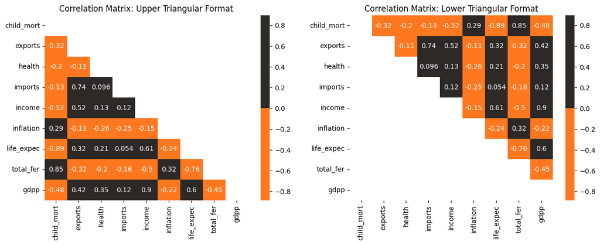

```python
# Exclude the 'country' column for correlation matrix calculation
corr_matrix = data.drop('country', axis=1).corr()

ut = np.triu(corr_matrix)
lt = np.tril(corr_matrix)

fig, ax = plt.subplots(nrows=1, ncols=2, figsize=(15, 5))
plt.subplot(1, 2, 1)
sns.heatmap(corr_matrix, cmap=colors, annot=True, cbar=True, mask=ut)
plt.title('Correlation Matrix: Upper Triangular Format')

plt.subplot(1, 2, 2)
sns.heatmap(corr_matrix, cmap=colors, annot=True, cbar=True, mask=lt)
plt.title('Correlation Matrix: Lower Triangular Format')
```

```python
df1 = pd.DataFrame()
df1['Health'] = (data['child_mort'] / data['child_mort'].mean()) + (data['health'] / data['health'].mean()) + (data['life_expec'] / data['life_expec'].mean()) + (data['total_fer'] / data['total_fer'].mean())
df1['Trade'] = (data['imports'] / data['imports'].mean()) + (data['exports'] / data['exports'].mean())
df1['Finance'] = (data['income'] / data['income'].mean()) + (data['inflation'] / data['inflation'].mean()) + (data['gdpp'] / data['gdpp'].mean())
df1.head()
```

|  | Health | Trade | Finance |
| --- | --- | --- | --- |
| 0 | 6.24 | 1.20 | 1.35 |
| 1 | 3.04 | 1.72 | 1.47 |
| 2 | 3.39 | 1.60 | 3.17 |
| 3 | 6.47 | 2.43 | 3.49 |
| 4 | 2.96 | 2.36 | 2.24 |

```python
from sklearn.preprocessing import StandardScaler, MinMaxScaler
mms = MinMaxScaler()
ss = StandardScaler()

df1['Health'] = mms.fit_transform(df1[['Health']])
df1['Trade'] = mms.fit_transform(df1[['Trade']])
df1['Finance'] = mms.fit_transform(df1[['Finance']])
df1.insert(loc = 0, value = list(data['country']), column = 'country')
df1.head()
```

|  | country | Health | Trade | Finance |
| --- | --- | --- | --- | --- |
| 0 | Afghanistan | 0.63 | 0.14 | 0.08 |
| 1 | Albania | 0.13 | 0.20 | 0.09 |
| 2 | Algeria | 0.18 | 0.19 | 0.21 |
| 3 | Angola | 0.66 | 0.28 | 0.24 |
| 4 | Antigua and Barbuda | 0.12 | 0.28 | 0.15 |